# Customer Churn Analysis — Part 1: Data Preparation

**Project:** Customer Churn Analysis for Advanced Telecommunications Solutions (ATS)

**Notebook role:** Data Engineer — Preprocessing and Feature Engineering

**Author:** Ruyu (Grace) Liu

### Purpose of this notebook

This notebook covers the foundational data preparation stage of the project:

1. Load and inspect the raw dataset
2. Clean the data (missing values, duplicates, outliers)
3. Explore the data (EDA)
4. Encode categorical variables
5. Scale/normalise numeric features
6. Split into train/test sets
7. Export processed datasets for downstream use

**Downstream consumers of this notebook's output:**

- **Part 2 — Clustering Analysis** needs a scaled version of `tenure` and `MonthlyCharges` only.
- **Part 3 — Predictive Modeling (ANN)** needs the full feature set, encoded and scaled, split into train/test sets.

### Sprint / Task Mapping (Jira reference)

This notebook corresponds to **Sprint 1 — Epic: Data Preparation**, broken down into the following tasks:

| Task | Notebook Section(s) |
| --- | --- |
| Load dataset & initial inspection | Sections 1–3 |
| Data cleaning (missing values, duplicates, outliers) | Section 4 |
| Exploratory Data Analysis (EDA) | Section 5 |
| Feature encoding (categorical variables) | Section 6 |
| Feature scaling / normalisation | Section 7 |
| Train/test split & export processed data | Sections 8–9 |

Each section below is tagged inline with its corresponding Jira task for traceability.

> 🗂️ **Jira Task — Sprint 1 (Epic: Data Preparation):** Load dataset & initial inspection

## 1. Import Libraries

```python
# Core data handling
import pandas as pd
import numpy as np

# Visualisation
import matplotlib.pyplot as plt
import seaborn as sns

# Preprocessing
from sklearn.preprocessing import StandardScaler, LabelEncoder
from sklearn.model_selection import train_test_split

# Display settings
sns.set_style("whitegrid")
plt.rcParams["figure.figsize"] = (7, 4)
pd.set_option("display.max_columns", None)

print("Libraries loaded.")
```

```
Libraries loaded.
```

## 2. Load Dataset

Loading a working copy of the raw dataset (`Dataset_ATS_v2.csv`). The original file is kept untouched in its source location — all loading, cleaning, and transformation steps below operate only on this copy, so the raw data can always be re-referenced if needed.

```python
df = pd.read_csv("../data/Dataset_ATS_v2 copy.csv")
print(f"Shape: {df.shape[0]} rows, {df.shape[1]} columns")
df.head()
```

```
Shape: 7043 rows, 10 columns
```

|  | gender | SeniorCitizen | Dependents | tenure | PhoneService | MultipleLines | InternetService | Contract | MonthlyCharges | Churn |
| --- | --- | --- | --- | --- | --- | --- | --- | --- | --- | --- |
| 0 | Female | 0 | No | 1 | No | No | DSL | Month-to-month | 25 | Yes |
| 1 | Male | 0 | No | 41 | Yes | No | DSL | One year | 25 | No |
| 2 | Female | 0 | Yes | 52 | Yes | No | DSL | Month-to-month | 19 | No |
| 3 | Female | 0 | No | 1 | Yes | No | DSL | One year | 76 | Yes |
| 4 | Male | 0 | No | 67 | Yes | No | Fiber optic | Month-to-month | 51 | No |

**Note:** The dataset contains 7,043 customer records across 10 columns, covering demographic information (gender, SeniorCitizen, Dependents), service usage (tenure, PhoneService, MultipleLines, InternetService, Contract, MonthlyCharges), and the target label `Churn`.

### Data Dictionary

| Feature | Type | Values | Description |
| --- | --- | --- | --- |
| `gender` | Categorical (binary) | Female, Male | Customer's gender |
| `SeniorCitizen` | Numeric (binary, 0/1) | 0 = No, 1 = Yes | Whether the customer is a senior citizen |
| `Dependents` | Categorical (binary) | No, Yes | Whether the customer has dependents (e.g. children, other family members) |
| `tenure` | Numeric (continuous) | 0–72 | Number of months the customer has been with the company |
| `PhoneService` | Categorical (binary) | No, Yes | Whether the customer subscribes to phone service |
| `MultipleLines` | Categorical (binary) | No, Yes | Whether the customer has multiple phone lines |
| `InternetService` | Categorical | DSL, Fiber optic | Type of internet service the customer subscribes to |
| `Contract` | Categorical (3 classes) | Month-to-month, One year, Two year | Length/type of the customer's contract |
| `MonthlyCharges` | Numeric (continuous) | 18–119 | Customer's monthly bill amount, in dollars |
| `Churn` | Categorical (binary) — **target variable** | No, Yes | Whether the customer has churned (left the company) |

**Notes on this dataset:**

- There is no unique customer ID column — each row represents one customer record, identified only by its combination of feature values.
- `tenure` and `MonthlyCharges` are the two features used for the Clustering Analysis (Part 2), as specified in the project brief.
- `Churn` is the target label used for the Predictive Modeling (ANN) in Part 3, and is not used as a predictor feature.

## 3. Initial Inspection

```python
df.info()
```

```
<class 'pandas.core.frame.DataFrame'>
RangeIndex: 7043 entries, 0 to 7042
Data columns (total 10 columns):
 #   Column           Non-Null Count  Dtype
---  ------           --------------  -----
 0   gender           7043 non-null   object
 1   SeniorCitizen    7043 non-null   int64
 2   Dependents       7043 non-null   object
 3   tenure           7043 non-null   int64
 4   PhoneService     7043 non-null   object
 5   MultipleLines    7043 non-null   object
 6   InternetService  7043 non-null   object
 7   Contract         7043 non-null   object
 8   MonthlyCharges   7043 non-null   int64
 9   Churn            7043 non-null   object
dtypes: int64(3), object(7)
memory usage: 550.4+ KB
```

```python
# Data types and a quick statistical summary of numeric columns
df.describe()
```

|  | SeniorCitizen | tenure | MonthlyCharges |
| --- | --- | --- | --- |
| count | 7043.000000 | 7043.000000 | 7043.000000 |
| mean | 0.162147 | 32.371149 | 64.758768 |
| std | 0.368612 | 24.559481 | 30.091650 |
| min | 0.000000 | 0.000000 | 18.000000 |
| 25% | 0.000000 | 9.000000 | 36.000000 |
| 50% | 0.000000 | 29.000000 | 70.000000 |
| 75% | 0.000000 | 55.000000 | 90.000000 |
| max | 1.000000 | 72.000000 | 119.000000 |

**Observations:**

- `SeniorCitizen`, `tenure`, and `MonthlyCharges` are numeric; the remaining columns (including the target `Churn`) are categorical/text.
- `tenure` ranges from 0–72 (months), `MonthlyCharges` ranges from 18–119. Both fall within plausible real-world ranges for a telecom provider.
- No obvious formatting issues (e.g. mixed types, stray whitespace) are visible at this stage — this will be verified further below.

> 🗂️ **Jira Task — Sprint 1 (Epic: Data Preparation):** Data cleaning (missing values, duplicates, outliers)

## 4. Data Cleaning

### 4.1 Missing Values

```python
missing = df.isnull().sum()
missing_pct = (missing / len(df) * 100).round(2)
pd.DataFrame({"missing_count": missing, "missing_%": missing_pct})
```

|  | missing_count | missing_% |
| --- | --- | --- |
| gender | 0 | 0.0 |
| SeniorCitizen | 0 | 0.0 |
| Dependents | 0 | 0.0 |
| tenure | 0 | 0.0 |
| PhoneService | 0 | 0.0 |
| MultipleLines | 0 | 0.0 |
| InternetService | 0 | 0.0 |
| Contract | 0 | 0.0 |
| MonthlyCharges | 0 | 0.0 |
| Churn | 0 | 0.0 |

**Finding:** No missing values were found in any column.

**Decision:** No imputation or row deletion is required for this dataset. (For reference — had missing data been present, the general approach would depend on the proportion missing and the feature's importance: e.g. drop rows if missingness is minimal and random; impute with median/mode for numeric/categorical features if missingness is moderate; consider dropping the column entirely only if a large majority of values were missing and the feature wasn't critical.)

### 4.2 Duplicate Rows

**Decision:** These rows are **kept, not dropped**, for now.

This dataset has no unique customer ID column, so there is no way to confirm whether these are truly the same customer recorded twice, or different customers who happen to share identical values across all 10 fields. Since `tenure` and `MonthlyCharges` are the two features used directly in the Clustering Analysis (Part 2), removing these rows would directly affect the density of points K-Means uses to determine cluster centroids — a decision that shouldn't be made without more certainty.

**Recommendation:** This should be raised with the mentor via the PM, or checked against the Data Engineer training materials — the absence of a unique customer ID is unusual for a real-world dataset and worth confirming before deciding how to handle these rows.

```python
# Check for fully duplicated rows across all columns
duplicate_count = df.duplicated().sum()
print(f"Number of duplicate row patterns: {duplicate_count}")
print(f"Total rows involved (including first occurrence): {df.duplicated(keep=False).sum()}")

# Decision: rows are kept as-is — see markdown note above for reasoning
```

```
Number of duplicate row patterns: 302
Total rows involved (including first occurrence): 541
```

### 4.3 Outlier Check — All Features

Extending beyond `tenure` and `MonthlyCharges`, every feature is checked here for data quality issues — invalid values, unexpected categories, or implausible outliers — before moving into deeper exploratory analysis in Section 5. This is a sanity-check pass, not the full EDA narrative (which follows later).

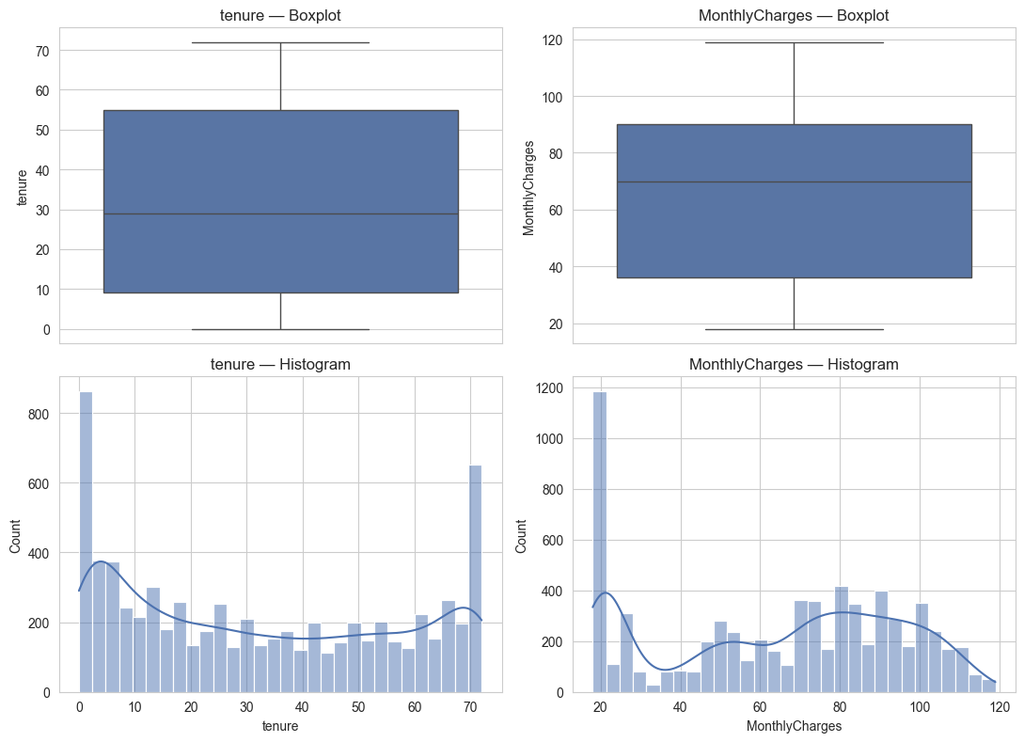

```python
# Visualise tenure and MonthlyCharges with both a boxplot (to spot outliers)
# and a histogram (to see the overall shape of the distribution)
fig, axes = plt.subplots(2, 2, figsize=(11, 8))
numeric_cols = ["tenure", "MonthlyCharges"]

for i, col in enumerate(numeric_cols):
    sns.boxplot(y=df[col], ax=axes[0, i], color="#4C72B0")
    axes[0, i].set_title(f"{col} — Boxplot")
    sns.histplot(df[col], bins=30, kde=True, ax=axes[1, i], color="#4C72B0")
    axes[1, i].set_title(f"{col} — Histogram")

plt.tight_layout()
plt.show()
```

```python
# Quantify potential outliers using the IQR method:
# any value beyond 1.5x the interquartile range from Q1/Q3 is flagged
for col in ["tenure", "MonthlyCharges"]:
    Q1, Q3 = df[col].quantile([0.25, 0.75])
    IQR = Q3 - Q1
    lower, upper = Q1 - 1.5 * IQR, Q3 + 1.5 * IQR
    outliers = df[(df[col] < lower) | (df[col] > upper)]
    print(f"{col}: IQR bounds = [{lower:.1f}, {upper:.1f}], outliers found = {len(outliers)}")
```

```
tenure: IQR bounds = [-60.0, 124.0], outliers found = 0
MonthlyCharges: IQR bounds = [-45.0, 171.0], outliers found = 0
```

```python
# Print unique values for every categorical field (including binary numeric SeniorCitizen
# and the target Churn) — this catches typos, inconsistent labels, or unexpected categories
cat_all = ["gender", "SeniorCitizen", "Dependents", "PhoneService",
           "MultipleLines", "InternetService", "Contract", "Churn"]

for col in cat_all:
    print(f"{col}: {sorted(df[col].astype(str).unique())}")
```

```
gender: ['Female', 'Male']
SeniorCitizen: ['0', '1']
Dependents: ['No', 'Yes']
PhoneService: ['No', 'Yes']
MultipleLines: ['No', 'Yes']
InternetService: ['DSL', 'Fiber optic']
Contract: ['Month-to-month', 'One year', 'Two year']
Churn: ['No', 'Yes']
```

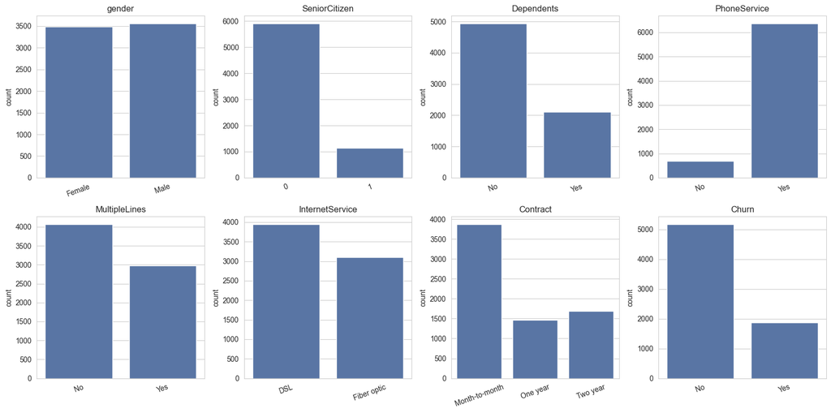

```python
# Visualise the count of each category for every categorical field,
# to check for class imbalance or unexpectedly rare categories
fig, axes = plt.subplots(2, 4, figsize=(16, 8))
axes = axes.flatten()

for i, col in enumerate(cat_all):
    order = sorted(df[col].astype(str).unique())
    sns.countplot(x=df[col].astype(str), order=order, ax=axes[i], color="#4C72B0")
    axes[i].set_title(col)
    axes[i].set_xlabel("")
    for label in axes[i].get_xticklabels():
        label.set_rotation(20)

plt.tight_layout()
plt.show()
```

**Finding:**

- No missing, malformed, or unexpected category values were found in any of the 8 categorical fields — each contains only its expected set of values (e.g. `Contract` has exactly 3 categories, all others are binary).
- `tenure` shows two notable spikes: a large group at 0 (new customers) and another at 72 (the maximum observed value, likely long-tenured customers or a cap in the data collection window). Both are plausible, real patterns rather than data errors.
- `MonthlyCharges` shows a spike around $18–20, consistent with customers on a low-cost base plan.
- No IQR-based outliers were flagged in `tenure` or `MonthlyCharges` (see quantitative check above).

**Decision:** No rows are removed at this stage. All feature distributions appear valid and consistent with real-world telecom customer behaviour.

> 🗂️ **Jira Task — Sprint 1 (Epic: Data Preparation):** Exploratory Data Analysis (EDA)

## 5. Exploratory Data Analysis (EDA)

### 5.1 Target Variable — `Churn`

[figure not shown]

```
Churn
No     5174
Yes    1869
Name: count, dtype: int64
Churn
No     73.5
Yes    26.5
Name: count, dtype: float64
```

```python
churn_counts = df["Churn"].value_counts()
churn_pct = (churn_counts / len(df) * 100).round(1)

fig, ax = plt.subplots(figsize=(8, 4))
sns.countplot(x="Churn", data=df, palette=["#4C72B0", "#C44E52"], ax=ax)
ax.set_title("Customer Churn Distribution")
for i, (count, pct) in enumerate(zip(churn_counts, churn_pct)):
    ax.text(i, count + 30, f"{count}\n({pct}%)", ha="center")
plt.show()

print(churn_counts)
print(churn_pct)
```

**Finding:** The dataset is moderately imbalanced — roughly a 3:1 split between customers who stayed (`No`) and those who churned (`Yes`). This is a normal pattern for churn datasets and is worth flagging for the Predictive Modeling notebook (Part 3), where class imbalance can affect model evaluation (e.g. accuracy alone can be misleading; precision/recall/F1 matter more).

This imbalance is also why the train/test split in Section 8 uses **stratified sampling** (`stratify=y`) — this ensures the ~73/27 Churn ratio observed here is preserved in both the training and test sets, rather than risking an uneven split where one set ends up with a noticeably different churn rate purely by chance.

### 5.2 Numeric Feature Distributions — `tenure` and `MonthlyCharges`

**Note:** The visualisations in this section revisit `tenure`, `MonthlyCharges`, and the categorical features already plotted in Section 4.3. The purpose here is different, though: Section 4.3 checked these distributions for **data quality issues** (outliers, unexpected categories, invalid values). This section instead explores the **trends and patterns** within each variable — what the distribution shape suggests about the customer base, and how it might relate to churn behaviour — as a foundation for the deeper analysis that follows in Sections 5.4 and 5.5.

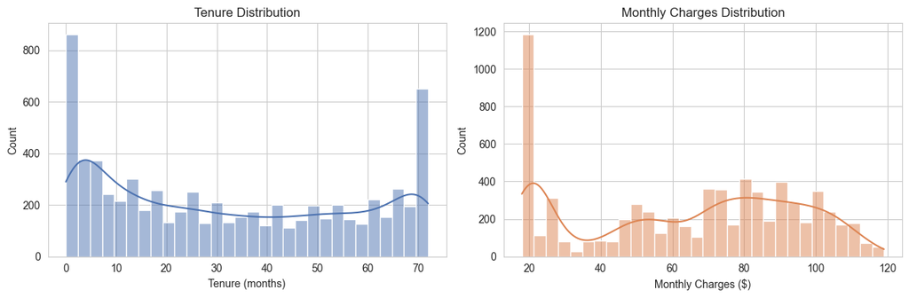

```python
fig, axes = plt.subplots(1, 2, figsize=(12, 4))

sns.histplot(df["tenure"], bins=30, kde=True, ax=axes[0], color="#4C72B0")
axes[0].set_title("Tenure Distribution")
axes[0].set_xlabel("Tenure (months)")

sns.histplot(df["MonthlyCharges"], bins=30, kde=True, ax=axes[1], color="#DD8452")
axes[1].set_title("Monthly Charges Distribution")
axes[1].set_xlabel("Monthly Charges ($)")

plt.tight_layout()
plt.show()
```

**Finding:**

- `tenure` shows a somewhat bimodal pattern — a large group of relatively new customers (low tenure) and another cluster of long-standing customers approaching 72 months. This hints that natural customer groupings may already exist in the data, which is a good early sign for the clustering work in Part 2.
- `MonthlyCharges` is more spread out, with a rise around the lower end (customers on basic/no add-on plans) and a broader spread at higher charges (customers with more services).

### 5.3 Categorical Feature Distributions

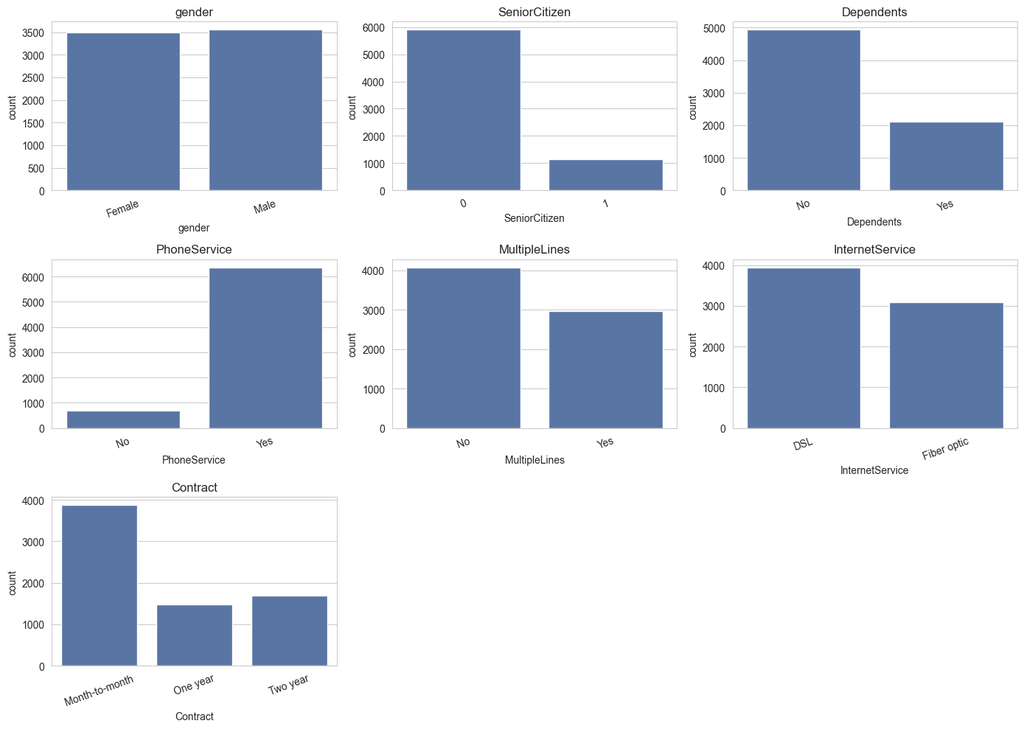

```python
cat_cols = ["gender", "SeniorCitizen", "Dependents", "PhoneService",
            "MultipleLines", "InternetService", "Contract"]

fig, axes = plt.subplots(3, 3, figsize=(14, 10))
axes = axes.flatten()

for i, col in enumerate(cat_cols):
    sns.countplot(x=col, data=df, ax=axes[i], color="#4C72B0")
    axes[i].set_title(col)
    axes[i].tick_params(axis="x", rotation=20)

# Hide unused subplots
for j in range(len(cat_cols), len(axes)):
    axes[j].axis("off")

plt.tight_layout()
plt.show()
```

### 5.4 `tenure` vs `MonthlyCharges`, Coloured by Churn

This view is particularly relevant to the Clustering Analysis in Part 2, since these are the two features that will define the clusters.

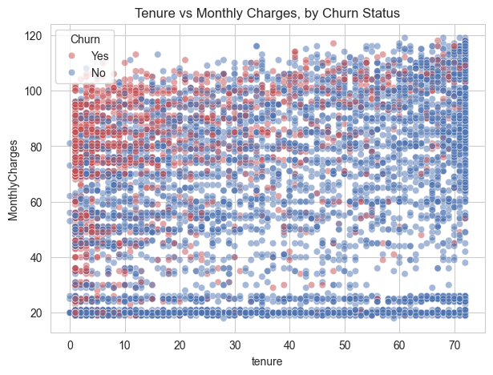

```python
fig, ax = plt.subplots(figsize=(7, 5))
sns.scatterplot(
    data=df, x="tenure", y="MonthlyCharges", hue="Churn",
    alpha=0.5, palette={"Yes": "#C44E52", "No": "#4C72B0"}, ax=ax
)
ax.set_title("Tenure vs Monthly Charges, by Churn Status")
plt.show()
```

**Finding:** Churned customers (red) are visibly concentrated in the **low-tenure, higher-charge** region of the plot, while long-tenure customers (regardless of charge level) churn far less often. This is a strong early signal that tenure and monthly charges alone can meaningfully separate customer segments by churn risk — a good justification for using exactly these two features in the clustering work.

### 5.5 Correlation Between Numeric Features

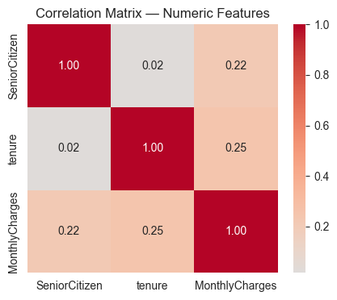

```python
numeric_df = df[["SeniorCitizen", "tenure", "MonthlyCharges"]]
corr = numeric_df.corr()

fig, ax = plt.subplots(figsize=(5, 4))
sns.heatmap(corr, annot=True, cmap="coolwarm", center=0, ax=ax, fmt=".2f")
ax.set_title("Correlation Matrix — Numeric Features")
plt.show()
```

**Finding:** `tenure` and `MonthlyCharges` show a weak positive correlation — they capture largely independent information about a customer, which supports using both together as complementary clustering dimensions rather than one being redundant given the other.

> 🗂️ **Jira Task — Sprint 1 (Epic: Data Preparation):** Feature encoding (categorical variables)

## 6. Feature Encoding

Categorical variables need to be converted to numeric form before they can be used in modelling (particularly for the ANN in Part 3; the Clustering notebook in Part 2 only needs the numeric `tenure`/`MonthlyCharges` columns and does not require this encoded set).

**Approach:**

- **Binary categorical variables** (`gender`, `Dependents`, `PhoneService`, `MultipleLines`, `InternetService`, `Churn`) → Label Encoding (0/1), since each has exactly two categories.
- **Multi-class variable** (`Contract`, 3 categories) → One-Hot Encoding, to avoid implying a false ordinal relationship between contract types.

```python
df_encoded = df.copy()

# Binary categorical columns
binary_cols = ["gender", "Dependents", "PhoneService", "MultipleLines", "InternetService", "Churn"]

label_encoders = {}
for col in binary_cols:
    le = LabelEncoder()
    df_encoded[col] = le.fit_transform(df_encoded[col])
    label_encoders[col] = dict(zip(le.classes_, le.transform(le.classes_)))

# Show the encoding mapping used for each binary column, for transparency
for col, mapping in label_encoders.items():
    print(f"{col}: {mapping}")
```

```
gender: {'Female': 0, 'Male': 1}
Dependents: {'No': 0, 'Yes': 1}
PhoneService: {'No': 0, 'Yes': 1}
MultipleLines: {'No': 0, 'Yes': 1}
InternetService: {'DSL': 0, 'Fiber optic': 1}
Churn: {'No': 0, 'Yes': 1}
```

```python
# One-hot encode the multi-class Contract column
df_encoded = pd.get_dummies(df_encoded, columns=["Contract"], prefix="Contract")

# Convert the new one-hot columns to int (0/1) rather than bool, for consistency
contract_cols = [c for c in df_encoded.columns if c.startswith("Contract_")]
df_encoded[contract_cols] = df_encoded[contract_cols].astype(int)

df_encoded.head()
```

|  | gender | SeniorCitizen | Dependents | tenure | PhoneService | MultipleLines | InternetService | MonthlyCharges | Churn | Contract_Month-to-month | Contract_One year | Contract_Two year |
| --- | --- | --- | --- | --- | --- | --- | --- | --- | --- | --- | --- | --- |
| 0 | 0 | 0 | 0 | 1 | 0 | 0 | 0 | 25 | 1 | 1 | 0 | 0 |
| 1 | 1 | 0 | 0 | 41 | 1 | 0 | 0 | 25 | 0 | 0 | 1 | 0 |
| 2 | 0 | 0 | 1 | 52 | 1 | 0 | 0 | 19 | 0 | 1 | 0 | 0 |
| 3 | 0 | 0 | 0 | 1 | 1 | 0 | 0 | 76 | 1 | 0 | 1 | 0 |
| 4 | 1 | 0 | 0 | 67 | 1 | 0 | 1 | 51 | 0 | 1 | 0 | 0 |

**Result:** All categorical variables are now numeric. `SeniorCitizen` was already 0/1 in the raw data and required no changes. The dataset now has more columns than the original due to one-hot encoding of `Contract`.

> 🗂️ **Jira Task — Sprint 1 (Epic: Data Preparation):** Feature scaling / normalisation

## 7. Feature Scaling

Two scaled outputs are prepared here for the two different downstream needs:

1. **Clustering-ready features** — `tenure` and `MonthlyCharges` only, scaled with `StandardScaler`. K-Means relies on Euclidean distance, so these two features (which are on very different scales — months vs. dollars) must be standardised, or `MonthlyCharges` will dominate the distance calculation.
2. **Full feature set for ANN** — all encoded features scaled together, since neural networks generally train better and converge faster on standardised inputs.

```python
# --- 1. Clustering-ready scaled features ---
cluster_features = df_encoded[["tenure", "MonthlyCharges"]].copy()

scaler_cluster = StandardScaler()
cluster_features_scaled = pd.DataFrame(
    scaler_cluster.fit_transform(cluster_features),
    columns=["tenure_scaled", "MonthlyCharges_scaled"]
)

cluster_features_scaled.describe()
```

|  | tenure_scaled | MonthlyCharges_scaled |
| --- | --- | --- |
| count | 7.043000e+03 | 7.043000e+03 |
| mean | -2.446495e-17 | -1.311523e-16 |
| std | 1.000071e+00 | 1.000071e+00 |
| min | -1.318165e+00 | -1.553989e+00 |
| 25% | -9.516817e-01 | -9.557738e-01 |
| 50% | -1.372744e-01 | 1.741880e-01 |
| 75% | 9.214551e-01 | 8.388714e-01 |
| max | 1.613701e+00 | 1.802662e+00 |

```python
# --- 2. Full feature set scaled for ANN ---
# Separate features and target
X = df_encoded.drop(columns=["Churn"])
y = df_encoded["Churn"]

scaler_full = StandardScaler()
X_scaled = pd.DataFrame(scaler_full.fit_transform(X), columns=X.columns)

X_scaled.describe().round(2)
```

|  | gender | SeniorCitizen | Dependents | tenure | PhoneService | MultipleLines | InternetService | MonthlyCharges | Contract_Month-to-month | Contract_One year | Contract_Two year |
| --- | --- | --- | --- | --- | --- | --- | --- | --- | --- | --- | --- |
| count | 7043.00 | 7043.00 | 7043.00 | 7043.00 | 7043.00 | 7043.00 | 7043.00 | 7043.00 | 7043.00 | 7043.00 | 7043.00 |
| mean | -0.00 | -0.00 | 0.00 | -0.00 | 0.00 | -0.00 | -0.00 | -0.00 | -0.00 | -0.00 | -0.00 |
| std | 1.00 | 1.00 | 1.00 | 1.00 | 1.00 | 1.00 | 1.00 | 1.00 | 1.00 | 1.00 | 1.00 |
| min | -1.01 | -0.44 | -0.65 | -1.32 | -3.05 | -0.85 | -0.89 | -1.55 | -1.11 | -0.51 | -0.56 |
| 25% | -1.01 | -0.44 | -0.65 | -0.95 | 0.33 | -0.85 | -0.89 | -0.96 | -1.11 | -0.51 | -0.56 |
| 50% | 0.99 | -0.44 | -0.65 | -0.14 | 0.33 | -0.85 | -0.89 | 0.17 | 0.90 | -0.51 | -0.56 |
| 75% | 0.99 | -0.44 | 1.53 | 0.92 | 0.33 | 1.17 | 1.13 | 0.84 | 0.90 | -0.51 | -0.56 |
| max | 0.99 | 2.27 | 1.53 | 1.61 | 0.33 | 1.17 | 1.13 | 1.80 | 0.90 | 1.94 | 1.78 |

**Note:** Two separate scalers are used deliberately — the clustering scaler is fitted only on `tenure`/`MonthlyCharges` (matching exactly what Part 2 needs), while the full-feature scaler is fitted across all predictor columns for Part 3. Keeping these separate avoids Part 2 unintentionally depending on columns it doesn't use.

> 🗂️ **Jira Task — Sprint 1 (Epic: Data Preparation):** Train/test split & export processed data

## 8. Train/Test Split

This split is prepared for the Predictive Modeling notebook (Part 3). A stratified split is used to preserve the ~73/27 Churn ratio observed in Section 5.1 across both sets, since the dataset is moderately imbalanced.

The Clustering Analysis in Part 2 does not use this split — clustering is typically performed on the full dataset, since it's an unsupervised, exploratory technique rather than one being evaluated on unseen data.

```python
X_train, X_test, y_train, y_test = train_test_split(
    X_scaled, y, test_size=0.2, random_state=42, stratify=y
)

print(f"Train set: {X_train.shape[0]} rows")
print(f"Test set:  {X_test.shape[0]} rows")
print(f"\nChurn rate — train: {y_train.mean():.3f}, test: {y_test.mean():.3f}")
```

```
Train set: 5634 rows
Test set:  1409 rows

Churn rate — train: 0.265, test: 0.265
```

**Finding:** The stratified split preserves the churn ratio closely between train and test sets, so the test set will provide a representative evaluation of model performance in Part 3.

## 9. Export Processed Datasets

The following files are exported to `../data/processed/` for use in the next two notebooks:

[output not shown]

**Why `row_id` matters:** Neither `clustering_features_scaled.csv` nor `full_encoded_cleaned.csv` contains a customer ID (the source dataset doesn't have one — see Section 4.2). Since the Clustering Analysis in Part 2 trains K-Means on `clustering_features_scaled.csv` alone, but interpreting the resulting clusters requires joining the resulting cluster labels back to the categorical fields in `full_encoded_cleaned.csv`, both files need a shared key to join on reliably.

`row_id` is simply the row's position in the cleaned dataset at export time (0-indexed), added explicitly to both files so this join is safe regardless of whether either file gets re-sorted, filtered, or reloaded out of order later. The same reasoning applies to `ann_train.csv`/`ann_test.csv` — `train_test_split` reorders rows, so `row_id` is exported there too, preserving a traceable link back to the original dataset.

```python
import os
os.makedirs("../data/processed", exist_ok=True)

# --- 1. Clustering features (scaled), with row_id for safe joining later ---
cluster_features_scaled_out = cluster_features_scaled.copy()
cluster_features_scaled_out.insert(0, "row_id", df_encoded.index)
cluster_features_scaled_out.to_csv("../data/processed/clustering_features_scaled.csv", index=False)

# --- 2. Full cleaned + encoded dataset (unscaled), with row_id ---
full_encoded_out = df_encoded.copy()
full_encoded_out.insert(0, "row_id", df_encoded.index)
full_encoded_out.to_csv("../data/processed/full_encoded_cleaned.csv", index=False)

# --- 3. Train/test sets for ANN (scaled features + target), with row_id ---
# X_train/X_test retain their original pandas index from before the split,
# which is exported here explicitly as row_id for traceability
train_out = X_train.copy()
train_out.insert(0, "row_id", X_train.index)
train_out["Churn"] = y_train.values

test_out = X_test.copy()
test_out.insert(0, "row_id", X_test.index)
test_out["Churn"] = y_test.values

train_out.to_csv("../data/processed/ann_train.csv", index=False)
test_out.to_csv("../data/processed/ann_test.csv", index=False)

print("Exported files:")
for f in ["clustering_features_scaled.csv", "full_encoded_cleaned.csv", "ann_train.csv", "ann_test.csv"]:
    path = f"../data/processed/{f}"
    print(f" - {path} ({os.path.getsize(path):,} bytes)")
```

```
Exported files:
 - ../data/processed/clustering_features_scaled.csv (309,608 bytes)
 - ../data/processed/full_encoded_cleaned.csv (216,504 bytes)
 - ../data/processed/ann_train.csv (1,247,829 bytes)
 - ../data/processed/ann_test.csv (312,204 bytes)
```

## 10. Summary

**What this notebook did:**

- Loaded and inspected the raw dataset (7,043 rows × 10 columns)
- Confirmed no missing values; found 302 duplicate row patterns (541 rows) but **kept them**, since the dataset has no customer ID to confirm whether they are true duplicates or distinct customers with matching profiles — flagged for the PM/mentor to confirm
- Confirmed no outliers in `tenure`/`MonthlyCharges`, and no unexpected values across all other fields
- Explored the target variable (Churn, ~26.5% churn rate) and key feature distributions
- Found an early visual signal that churned customers cluster in the low-tenure/higher-charge region — a good justification for the clustering approach in Part 2
- Encoded all categorical variables (label encoding for binary, one-hot for `Contract`) into a single shared dataset used by both DAs
- Produced two purpose-built scaled feature sets: one for clustering (`tenure`/`MonthlyCharges` only), one for the ANN (full feature set)
- Created a stratified train/test split for predictive modelling, preserving the churn ratio
- Added a `row_id` column to all exported files, to allow cluster labels (Part 2) and any other downstream outputs to be safely joined back to the full dataset
- Exported all processed files for use in Parts 2 and 3

**Next steps:**

- **Part 2 (Clustering Analysis)** picks up from `clustering_features_scaled.csv`, and joins back to `full_encoded_cleaned.csv` via `row_id` for cluster interpretation and labelling
- **Part 3 (Predictive Modeling)** picks up from `ann_train.csv` / `ann_test.csv`